# Analisis de los coches (mtcars)

Ramon Ceballos

11/2/2021

# **Análisis de los coches (mtcars)**

## 1. Carga de datos

Vamos a trabajar con Python.

Importamos las librerías que vamos a usar en el análisis y cargamos los datos del dataset “mtcars” presente en ggplot.

```python
import numpy as np
import pandas as pd
import matplotlib.pyplot as plt
from ggplot import mtcars
```

Vemos si se han cargado los datos correctamente.

```python
data = mtcars
print(data.head(4))
```

```
##              name   mpg  cyl   disp   hp  drat     wt   qsec  vs  am  gear  \
## 0       Mazda RX4  21.0    6  160.0  110  3.90  2.620  16.46   0   1     4
## 1   Mazda RX4 Wag  21.0    6  160.0  110  3.90  2.875  17.02   0   1     4
## 2      Datsun 710  22.8    4  108.0   93  3.85  2.320  18.61   1   1     4
## 3  Hornet 4 Drive  21.4    6  258.0  110  3.08  3.215  19.44   1   0     3
##
##    carb
## 0     4
## 1     4
## 2     1
## 3     1
```

## 2. Medidas de centralización

Vemos que el índice se asigna por números que pone Python. Vamos a asignar el índice según el nombre del modelo del coche.

```python
data.index = data["name"]
```

A continuación hago la **media** para cada una de las columnas numéricas.

```python
print(data.mean())
```

```
## mpg      20.090625
## cyl       6.187500
## disp    230.721875
## hp      146.687500
## drat      3.596563
## wt        3.217250
## qsec     17.848750
## vs        0.437500
## am        0.406250
## gear      3.687500
## carb      2.812500
## dtype: float64
```

También se puede hacer la media por filas, aunque en este caso no tenga sentido.

```python
print(data.mean(axis=1))
```

```
## name
## Mazda RX4              29.907273
## Mazda RX4 Wag          29.981364
## Datsun 710             23.598182
## Hornet 4 Drive         38.739545
## Hornet Sportabout      53.664545
## Valiant                35.049091
## Duster 360             59.720000
## Merc 240D              24.634545
## Merc 230               27.233636
## Merc 280               31.860000
## Merc 280C              31.787273
## Merc 450SE             46.430909
## Merc 450SL             46.500000
## Merc 450SLC            46.350000
## Cadillac Fleetwood     66.232727
## Lincoln Continental    66.058545
## Chrysler Imperial      65.972273
## Fiat 128               19.440909
## Honda Civic            17.742273
## Toyota Corolla         18.814091
## Toyota Corona          24.888636
## Dodge Challenger       47.240909
## AMC Javelin            46.007727
## Camaro Z28             58.752727
## Pontiac Firebird       57.379545
## Fiat X1-9              18.928636
## Porsche 914-2          24.779091
## Lotus Europa           24.880273
## Ford Pantera L         60.971818
## Ferrari Dino           34.508182
## Maserati Bora          63.155455
## Volvo 142E             26.262727
## dtype: float64
```

La mediana de la distribución para cada columna sería:

```python
print(data.median())
```

```
## mpg      19.200
## cyl       6.000
## disp    196.300
## hp      123.000
## drat      3.695
## wt        3.325
## qsec     17.710
## vs        0.000
## am        0.000
## gear      4.000
## carb      2.000
## dtype: float64
```

La moda sería:

```python
print(data.mode())
```

```
##                    name   mpg  cyl   disp     hp  drat    wt   qsec   vs   am  \
## 0           AMC Javelin  10.4  8.0  275.8  110.0  3.07  3.44  17.02  0.0  0.0
## 1    Cadillac Fleetwood  15.2  NaN    NaN  175.0  3.92   NaN  18.90  NaN  NaN
## 2            Camaro Z28  19.2  NaN    NaN  180.0   NaN   NaN    NaN  NaN  NaN
## 3     Chrysler Imperial  21.0  NaN    NaN    NaN   NaN   NaN    NaN  NaN  NaN
## 4            Datsun 710  21.4  NaN    NaN    NaN   NaN   NaN    NaN  NaN  NaN
## 5      Dodge Challenger  22.8  NaN    NaN    NaN   NaN   NaN    NaN  NaN  NaN
## 6            Duster 360  30.4  NaN    NaN    NaN   NaN   NaN    NaN  NaN  NaN
## 7          Ferrari Dino   NaN  NaN    NaN    NaN   NaN   NaN    NaN  NaN  NaN
## 8              Fiat 128   NaN  NaN    NaN    NaN   NaN   NaN    NaN  NaN  NaN
## 9             Fiat X1-9   NaN  NaN    NaN    NaN   NaN   NaN    NaN  NaN  NaN
## 10       Ford Pantera L   NaN  NaN    NaN    NaN   NaN   NaN    NaN  NaN  NaN
## 11          Honda Civic   NaN  NaN    NaN    NaN   NaN   NaN    NaN  NaN  NaN
## 12       Hornet 4 Drive   NaN  NaN    NaN    NaN   NaN   NaN    NaN  NaN  NaN
## 13    Hornet Sportabout   NaN  NaN    NaN    NaN   NaN   NaN    NaN  NaN  NaN
```

[output cut: 52 more lines]

## 3. Medidas vs Distribuciones

La media y la mediana no siempre tienen que coincidir, y esto a su vez depende del sesgo de la distribución. Cuando la distribución es simétrica la mediana y la media coinciden. Cuando el sesgo es positivo o negativo, no coincidirán.

Genero unos datos aleatorios segun una normal y represento un plot de la función de densidad de dichos datos. A su vez, le añado una línea que coincida con la media y la mediana.

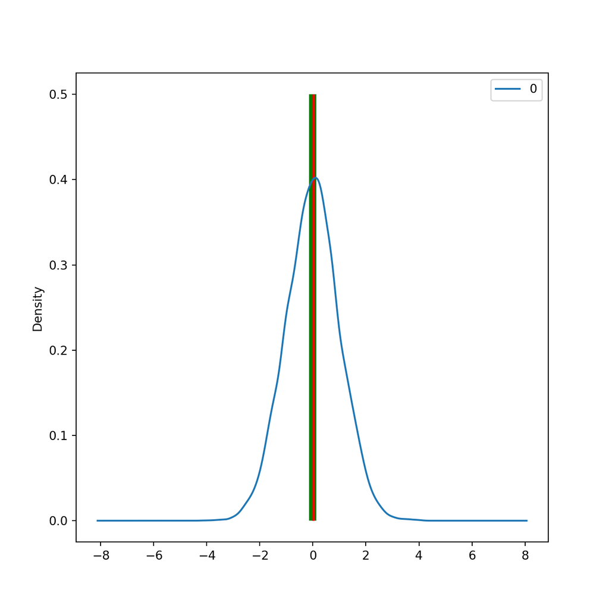

```python
norm_data = pd.DataFrame(np.random.normal(size=10000))

norm_data.plot(kind="density", figsize=(7,7))

plt.vlines(norm_data.mean(), ymin=0, ymax=0.5, linewidth=6.0, color="green")

plt.vlines(norm_data.median(), ymin=0, ymax=0.5, linewidth=2.0, color="red")

plt.show()
```

Vemos que la distribución es simétrica ya que la media y la mediana se superponen.

```python
skewed_data = pd.DataFrame(np.random.exponential(size=10000))

skewed_data.plot(kind="density", figsize=(7,7))

plt.vlines(skewed_data.mean(), ymin=0, ymax=0.7, linewidth=6.0, color="green")

plt.vlines(skewed_data.median(), ymin=0, ymax=0.7, linewidth=2.0, color="red")

plt.xlim(-2,5)
```

```
## (-2.0, 5.0)
```

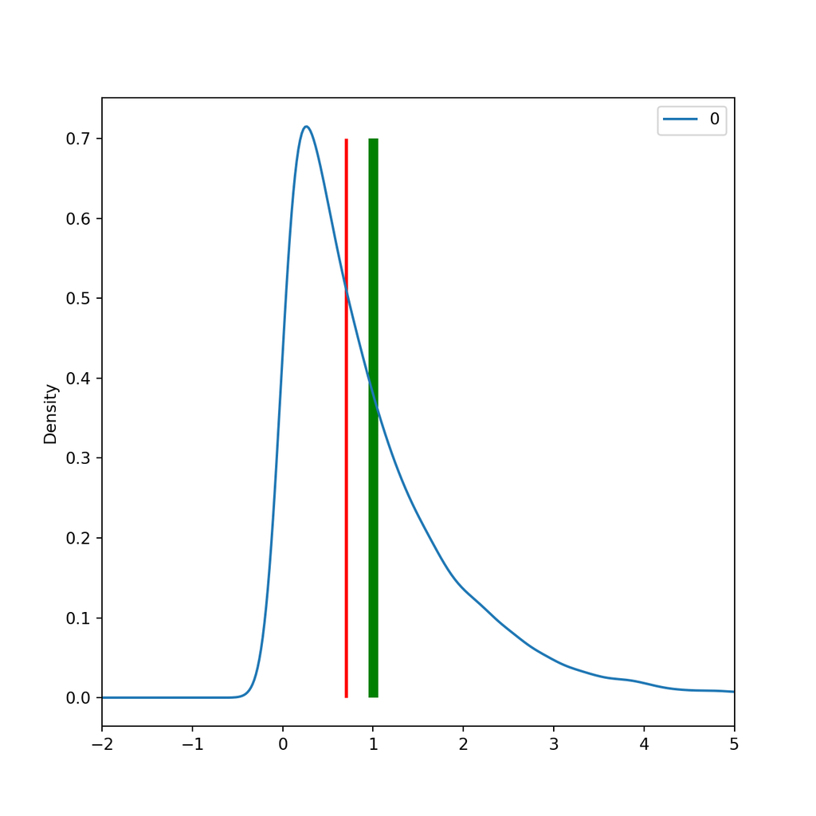

```python
plt.show()
```

Se observa que hay un sesgo positivo (asimetría hacia la dcha), y la mediana es más pequeña que la media.

Ahora vamos a generar una distribución normal de 50 datos (norm_data) con una serie de outliers (outliers) que siguen una distribución normal con $\mu = 15$. Juntamos ambos datos en un Data Frame mediante np.concatenate, y para indicar que se haga por columnas se pone axis=0.

```python
norm_data = np.random.normal(size=50)
outliers = np.random.normal(15,size=3)

combined_data = pd.DataFrame(np.concatenate((norm_data,outliers),axis=0))

combined_data.plot(kind="density", figsize=(7,7))

plt.vlines(combined_data.mean(), ymin=0, ymax=0.23, linewidth=6.0, color="green")

plt.vlines(combined_data.median(), ymin=0, ymax=0.23, linewidth=2.0, color="red")

plt.xlim(-10,20)
```

```
## (-10.0, 20.0)
```

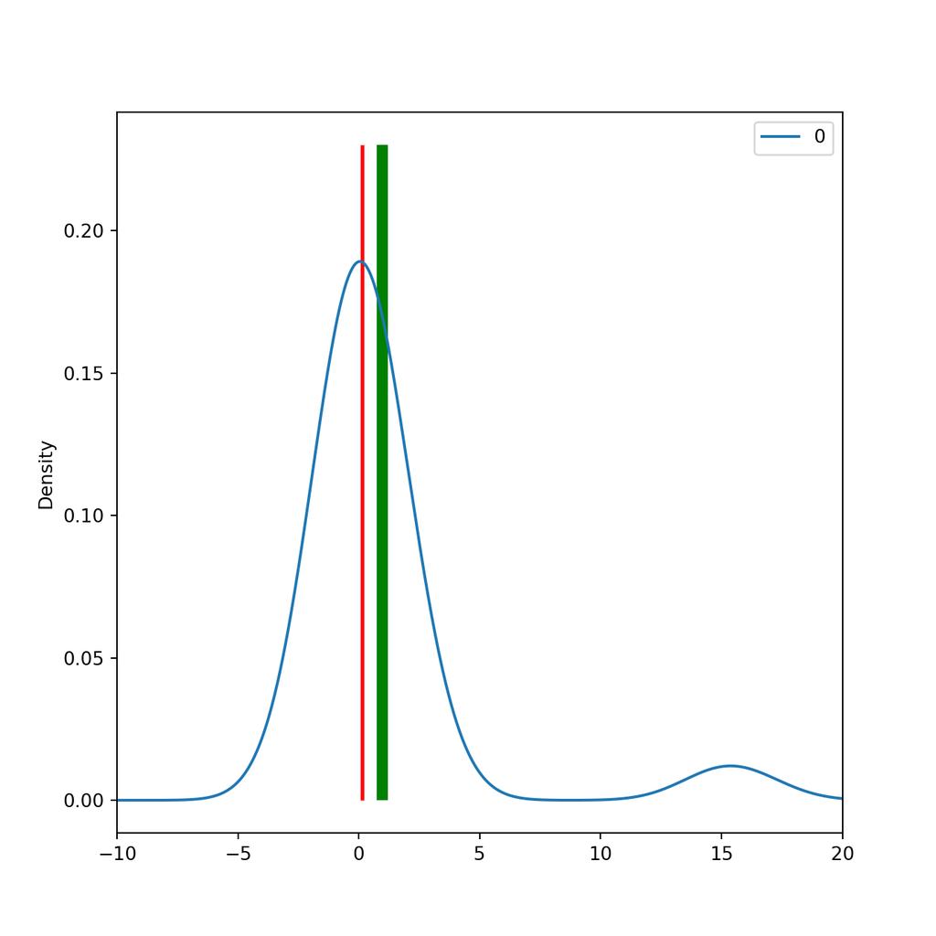

```python
plt.show()
```

Ahora la media aparece desplaza a la dcha, indicando la existencia de un sesgo. Esto se debe a los outliers que hemos incorporado. La mediana, por tanto, es más robusta que la media debido a que se resiente menos frente a la presencia de outliers. La media en cambio es muy sensible.

Vamos a investigar si dentro del dataset de mtcars, la variable mpg (millas por galón) está sesgada o no.

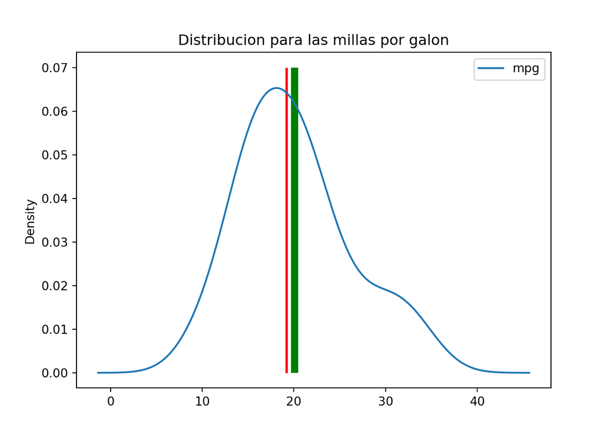

```python
data_mpg = data [["mpg"]]

data_mpg.plot(kind="density", title="Distribucion para las millas por galon")

plt.vlines(data_mpg.mean(),
color="green", linewidth=6,
ymin=0, ymax=0.07)

plt.vlines(data_mpg.median(),
color="red", linewidth=2,
ymin=0, ymax=0.07)

plt.show()
```

Vemos que la media se encuentra desplazada ligeramente a la derecha, lo cual indica que hay un ligero sesgo positivo.

Para al potencia (hp) lo desarrollaríamos de forma análoga.

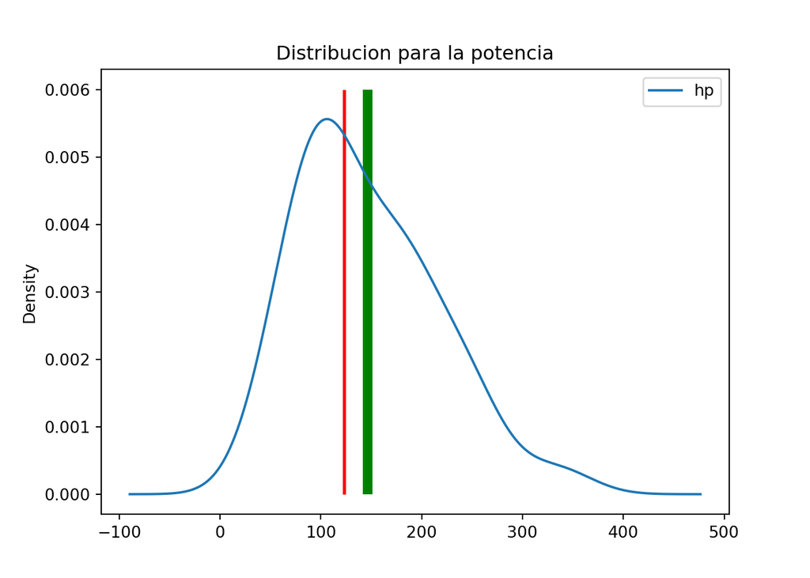

```python
data_hp = data [["hp"]]

data_hp.plot(kind="density", title="Distribucion para la potencia")

plt.vlines(data_hp.mean(),
color="green", linewidth=6,
ymin=0, ymax=0.006)

plt.vlines(data_hp.median(),
color="red", linewidth=2,
ymin=0, ymax=0.006)

plt.show()
```

También presenta un sesgo positivo la distribución de la variable de la potencia.

## 4. Medidas de dispersión

Estos estadísticos permiten estudiar la variación (diversidad) de los datos, mientras que las medidas de centralización dan una idea del valor más típico.

La dispersión se puede medir a través del **rango**. En este caso lo hacemos para las millas por galón.

```python
rang = max(data["mpg"])-min(data["mpg"])
print(rang)
```

```
## 23.5
```

Para poder describir la disepersión de una variable se emplean cinco percentiles distintos (five nums) que son: **mínmo, primer cuartil, mediana, tercer cuartil y el máximo**.

```python
five_nums = [data["mpg"].quantile(0),
         data["mpg"].quantile(0.25),
         data["mpg"].quantile(0.5),
         data["mpg"].quantile(0.75),
         data["mpg"].quantile(1)]

print(five_nums)
```

```
## [10.4, 15.425, 19.2, 22.8, 33.9]
```

Estos five nums aparecen al emplear la función describe() sobre la variable de estudio.

```python
print(data["mpg"].describe())
```

```
## count    32.000000
## mean     20.090625
## std       6.026948
## min      10.400000
## 25%      15.425000
## 50%      19.200000
## 75%      22.800000
## max      33.900000
## Name: mpg, dtype: float64
```

Para obtener el rango intercuartílico (IQR), se hace lo siguiente:

```python
rang_int = data["mpg"].quantile(0.75)-data["mpg"].quantile(0.25)
print(rang_int)
```

```
## 7.375
```

Ahora vamos a representar graficamente los datos estadísticos de medidas de dispersión.

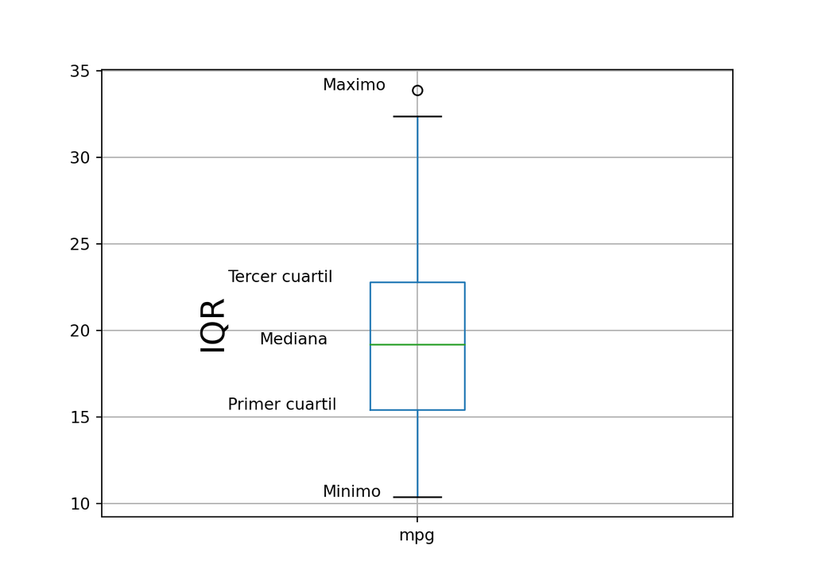

```python
plt.clf()

data.boxplot(column = "mpg", return_type="axes",
figsize=(5,5))

plt.text(0.7, y = data["mpg"].quantile(0.25),
s = "Primer cuartil")

plt.text(0.75, y = data["mpg"].quantile(0.5),
s = "Mediana")

plt.text(0.7, y = data["mpg"].quantile(0.75),
s = "Tercer cuartil")

plt.text(0.85, y = data["mpg"].quantile(0),
s = "Minimo")

plt.text(0.85, y = data["mpg"].quantile(1),
s = "Maximo")

plt.text(x=0.65, y=data["mpg"].quantile(0.5),
s="IQR", rotation=90,
size=20)

plt.show()
```

La **varianza y la desviación típica** son los estadísticos estrellas para determinar la dispersión de una variable.

```python
print(data["mpg"].var())
```

```
## 36.32410282258064
```

```python
print(data["mpg"].std())
```

```
## 6.026948052089104
```

Tanto la varianza como la desviación estándar son valores que proceden de la media, y esto significa que son medidas estadísticas muy influenciables a través de la curtosis y el sesgo de una distribución.

Debido a esto existe una tercera medida para el estudio de la dispersión de los datos. Es la **desviación mediana absoluta** (mad).

Para el cálculo de “mad” se resta cada valor contenido en la variable su mediana, dando el valor final en valor absoluto. Después se multiplica por el parámetro **k** que vale 1.4826. Este valor es más resistente a los outliers.

```python
mad = abs(data["mpg"]-data["mpg"].median())

k = 1.4826

print(mad.median()*k)
```

```
## 5.411490000000001
```

## 5. Medidas de forma de la distribución

En este apartado nos interesan dos estadísticos: el **sesgo** de la distribución y el coeficiente de **curtosis**.

El sesgo da información acerca de la simetría de la distribución, mientras que la curtosis da información sobre lo picuda que es la distribución (). Este coeficiente de curtosis indica la cantidad de datos que hay cercanos a la media, de manera que a mayor grado de curtosis, más escarpada (o apuntada) será la forma de la curva.

Son estadístico que nos da una idea de como se distribuyen los datos a lo largo de la distribución.

Para calcular el sesgo se emplea: “.skew()” en python.

Para calcular la curtosis se emplea: “.kurt()” en python.

```python
print(data["mpg"].skew())
```

```
## 0.6723771376290805
```

```python
print(data["mpg"].kurt())
```

```
## -0.0220062914240855
```

Se observa que el sesgo es ligeramente positivo, los datos están tirando hacia la derecha. Mientras, la curtosis está cercana a cero por lo que no existe un alto grado de escarpamiento para la curva (poco pincho).

Ahora vamos a crear datos en base a distintas distribuciones y las vamos a representar, para también calcularle la curtosis y el sesgo.

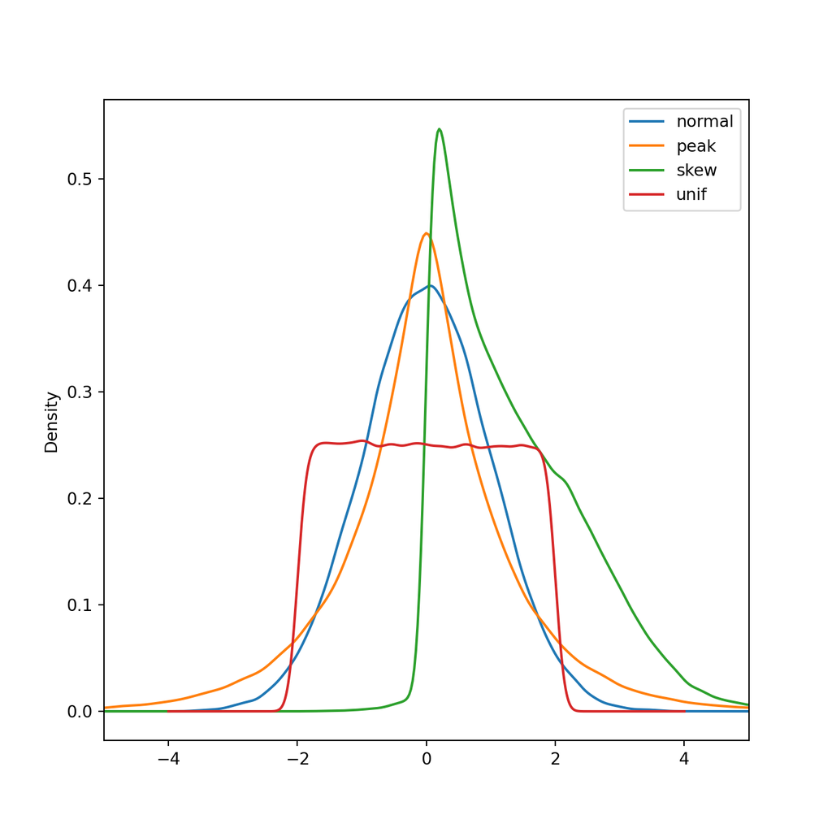

```python
norm =np.random.normal(size = 100000)

skew_data = np.concatenate((np.random.normal(size=35000)+2,np.random.exponential(size=65000)), axis=0)

unif = np.random.uniform(-2,2,size = 100000)

peak = np.concatenate((np.random.exponential(size=50000),
np.random.exponential(size=50000)*(-1)),
axis = 0)

data = pd.DataFrame({
"normal":norm,
"skew":skew_data,
"unif":unif,
"peak":peak
})


plt.clf()
data.plot(kind="density", figsize=(7,7),xlim= (-5,5))

plt.show()
```

```python
print("Normal, Sesgo = %f, Curtosis = %f" %(data["normal"].skew(), data["normal"].kurt()))
```

```
## Normal, Sesgo = -0.002199, Curtosis = 0.020849
```

```python
print("Normal+Exp, Sesgo = %f, Curtosis = %f" %(data["skew"].skew(), data["skew"].kurt()))
```

```
## Normal+Exp, Sesgo = 1.013797, Curtosis = 1.358345
```

```python
print("Uniforme, Sesgo = %f, Curtosis = %f" %(data["unif"].skew(), data["unif"].kurt()))
```

```
## Uniforme, Sesgo = 0.006546, Curtosis = -1.200415
```

```python
print("Suma de exponenciales, Sesgo = %f, Curtosis = %f" %(data["peak"].skew(), data["peak"].kurt()))
```

```
## Suma de exponenciales, Sesgo = -0.054704, Curtosis = 2.905834
```